# Pebble Count Data Analysis

Oliver Franklin & Nicci Zargarpour

2025-08-27

Welcome to what is intended to be a simple and efficient analysis of the data that you collected for your restoration project using the field methods we provided. While our scripts should take a lot of the effort out of data processing, figure generating, and statistical testing, you and your partners must apply your expertise to interpret the outputs in the context of your project.

You should be approaching data analysis with a set of established hypotheses, predictions, and plans for the various outcomes. If you are not familiar with the importance of *a priori* hypotheses and the dangers of data dredging, please spend some time reading up on these. Only once you have your hypotheses and predictions in mind (and ideally on paper) should you continue. We recommend revisiting your predictions and interpretations of possible outcomes before you run every single statistical test.

# Guidance Format

We have written these data analysis scripts in R markdown (.rmd files) and printed them as .html documents. As **Step 1** we recommend that you read through the .html files, which we printed using some example data. The .html files contain all the written guidance, but omit most of the underlying code. **Step 2** is to then open this file in both .html and .rmd formats, and begin processing your own data:

- You will notice the .rmd file contains a lot of R code. It should not be necessary for you to edit (or even understand) the vast majority of the code. However, there are points throughout the document (displayed as text visible in both .rmd and .html files) at which we prompt you to enter data or make decisions regarding parameters. At these points you will follow the instructions to make small edits to the code. The code that needs editing is also usually displayed in the .html document.
- We recommend having both the .rmd file open in RStudio, and the .html document open in a separate window. Although most of the code is hidden in the .html file, the documents are otherwise the same. You should use the .html document to guide you through step-by-step, rather than scrolling up and down in RStudio.
- You will need some basic understanding of R to use these scripts (e.g., one of many free self-paced online intro courses). We recommend installing [R](https://cran.rstudio.com/) and [RStudio](https://posit.co/download/rstudio-desktop/), and using the latter for viewing and modifying the .rmd file. If you are daunted by R, we think [Swirl](https://swirlstats.com/students.html) is a great learning resource that lets you learn R interactively in the software itself.
- You will work through the document from top to bottom and run the code chunks one by one as you encounter them. It is important that you run the code in the order it is presented. As you follow the instructions in RStudio, the results (figures, summaries of statistical tests etc.) will be displayed. The important results are also exported to a folder that you will be prompted to specify.
- Unless indicated otherwise in the text, you must run all of the code chunks. To ensure you don’t miss any chunks, you can use the ‘run all chunks above’ button in RStudio (grey triangle pointing down to green line) before running a chunk of interest.

If all of this looks daunting, don’t worry. R is a very popular language and many people have remarkable levels of expertise that they are usually happy to share.

# Data Wrangling

Data wrangling, or cleaning and structuring the data, is the first step before analysis. Hopefully there will not be too much you need to do manually, but there are often quirks in datasets, and taking the time to understand / correct them now will save you time in future.

First we combine all of the data that will be compared into one dataframe. These analyses are intended for BACI (before-after control-impact) assessments, so the dataframe should contain data for the restoration site and control/reference sites, and will (ultimately) have data across multiple years. Don’t worry if you only have data from one site and one year at this point, we will still produce metrics and figures for it. If you were unable to collect data at control/reference sites you can still learn a lot about your restoration site using these analyses, but familiarise yourself with the limitations of interpreting changes (or absence of change) when you do not have a well-matched control/reference.

## Before importing data

Please remember to keep the column names consistent with those in the data entry form that we provided (otherwise you will have to alter all the column names in our code to match). Note that b-axis length measurements should be in millimeters and particles (grains) < 1 mm should be classified as either sand (if gritty between fingers) or fines. If you encountered embedded particles, you can record this using by appending an upper case E to the b axis dimension (e.g., 12.2 E).

## Data import

You may have all of your data in one .csv file, or it may be in multiple .csv files (e.g., one per site and/or per year). If you have multiple .csv files, it is important to ensure that the column names and the formats of data entered (e.g. characters, numeric) are the same in all files. Our code should help aligning the formats of each column, but only if the column names are correct.

Once you have checked your column names are correct, place your .csv file(s) in a dedicated folder on your computer (containing no other files but those you intend to analyse here). In the below chunk of code, specify the directory name of the folder containing your files (enter this in the quotation marks for data_dir <- ” ” below).

```r
# Specify the directory containing the raw data files
data_dir <- "C:/Users/franklino/Documents/Restoration_Monitoring_Protocols/data_raw/Pebble Count/to_combine"
```

It may be necessary to subset within this dataframe if, e.g., you included more than one channel in your .csv files (surveys of multiple tributaries etc.). These scripts are intended to analyse one focal channel per reach, to compare it over time and with independent reference reaches that also feature one channel each. The code chunk below provides a method to subset your data by Site name, which can be modified to subset in other ways.

```r
# df <- subset(df, Site %in% c("Site 1", "Site 2"))

# if you included multiple channels in your .csv files, in the above line you can select only data that corresponds to the channels of interest. Simply replace the site names within the brackets with the sites you wish to select. Then, remove the # from the start of the line (anything in a line after # is not considered code, so will not run. If you have no subsetting, there should be a # before df <- subset)
```

Let’s take a brief look through the dataframe. Look out for any errors and explore unusual entries. Note that, if you recorded embedded pebbles, there will be new columns that indicate if the pebble is embedded or ‘free’

| Site | Date | Staff | Observer | Habitat_ID | GPS_WPT | Pebble_No. | B_Axis_T1 | B_Axis_T2 | B_Axis_T3 | Notes | Embedded_B_Axis_T1 | Embedded_B_Axis_T2 | Embedded_B_Axis_T3 |
| --- | --- | --- | --- | --- | --- | --- | --- | --- | --- | --- | --- | --- | --- |
| Resto 1 | 25-Sep-25 | NZ, OF | OF | 1 | - | 1 | 72 | 82 | 40 |  | free | free | free |
| Resto 1 | 25-Sep-25 | NZ, OF | OF | 1 | - | 2 | 83 | 42 | 76 |  | free | free | free |
| Resto 1 | 25-Sep-25 | NZ, OF | OF | 1 | - | 3 | 60 | 56 | 50 |  | free | free | free |
| Resto 1 | 25-Sep-25 | NZ, OF | OF | 1 | - | 4 | 61 | 66 | 47 |  | free | free | free |
| Resto 1 | 25-Sep-25 | NZ, OF | OF | 1 | - | 5 | 44 | 45 | 72 |  | free | free | free |
| Resto 1 | 25-Sep-25 | NZ, OF | OF | 1 | - | 6 | 67 | 39 | 74 |  | free | free | free |
| Resto 1 | 25-Sep-25 | NZ, OF | OF | 1 | - | 7 | 70 | 80 | 77 |  | free | free | free |
| Resto 1 | 25-Sep-25 | NZ, OF | OF | 1 | - | 8 | 62 | 65 | 64 |  | free | free | free |
| Resto 1 | 25-Sep-25 | NZ, OF | OF | 1 | - | 9 | 61 | 62 | 27 |  | free | free | free |
| Resto 1 | 25-Sep-25 | NZ, OF | OF | 1 | - | 10 | 56 | 68 | 27 |  | free | free | free |

[output cut: 278 more lines]

## Date format

In case your data collection spanned more than one day in any one of your sampling years, we also isolate just the year from the date column. Depending on the formatting of your date, you may need to adjust the code below to match your date format (e.g., change the part that says ‘dmy’ to ‘ymd’, ‘myd’, ‘dym’, etc.):

```r
df$parsed_date <- dmy(df$Date)  # Convert the date column to Date format
df$Year <- year(df$parsed_date)        # Extract the year
```

# Export Data

At this point, when running the code in RStudio, you will be prompted within the console to specify a folder for the output. We recommend a dedicated folder, or set of folders, that will contain all outputs from these scripts. Some of the outputs (dataframes) may be needed in other scripts, but many (figures, results of statistical tests) will be for your reference or for sharing with others. When prompted in the ‘console’ box, you will need to enter the folder location (e.g. C:/Users/ZARGARPOURN/Documents/SAR Team/Monitoring Protocols/R Code). If your R environment is cleared between scripts, you will be prompted again to specify the location. As such, you can clear your workplace intentionally if you want each script’s output in different folders.

We will now export the tidied dataframe so that it can be used in future analyses as needed. Check your file folder and the .csv files to see the data you exported before moving on.

# Pebble Count Analyses

The Pebble Count field survey collects surface substrate data within targeted mesohabitats. The protocol is primarily intended for use in riffles to document changes in the substrate particle size distribution associated with restoration actions. While this is of particular interest for salmonid spawning habitat, it is also useful more broadly, e.g. for monitoring changes in substrates associated with an altered sediment or flow regime.

This code estimates surface particle size distributions for the focal mesohabitat, which can be compared before/after restoration actions and/or between control and restoration sites. Particle size distributions are often also compared against benchmarks, such as published ranges of gravel sizes that are known to be used by particular salmonids.

Let’s briefly recall the survey methodology:

Field teams randomly selected three of the focal mesohabitat units (e.g., riffles) in the study reach. Within each focal mesohabitat unit, they visually estimated locations for three transects, and measured the b-axis diameter of 12 particles along each transect. At the end of the survey, teams will have measured 108 particles in total.

Optional: If you would like to plot the locations of each of your sites on a map, at this point you should create a .csv file with columns for ‘Site_Name’, ‘Longitude’, and ‘Latitude’. Specify the location of this file in the code below:

```r
# Load in Site location information, amend the path in the code below to link to your .csv of the location data
site_file <- "C:/Users/franklino/Documents/Restoration_Monitoring_Protocols/data_raw/Pebble Count/Sites.csv"
```

[interactive chart not shown]

## Cumulative Frequency Distribution Table

Eaton et al. (2019) developed a package called [GSDtools](https://zenodo.org/records/3229387) to support the analysis of pebble count data. We will use the functions they developed throughout our analyses, and we are very grateful for all their work.

First the data is structured to display the cumulative proportion of particles that are finer than given b-axis diameters, grouped by site and year. Your b-axis measurements will be binned into appropriate size classes and, for particles classified as either ‘sand’ or ‘fines’, we will assign b-axis diameter values of 0.25 mm for ‘sand’, and 0.016 mm for ‘fines’ (assigned based on values in the Wentworth scale).

| Site | Year | Size class / mm | Cumulative proportion | Count |
| --- | --- | --- | --- | --- |
| Ref 1 | 2025 | 8 | 0 | 0 |
| Ref 1 | 2025 | 11.31370849898476 | 0.009259259259259259 | 1 |
| Ref 1 | 2025 | 16 | 0.009259259259259259 | 0 |
| Ref 1 | 2025 | 22.62741699796952 | 0.009259259259259259 | 0 |
| Ref 1 | 2025 | 32 | 0.01851851851851852 | 1 |
| Ref 1 | 2025 | 45.25483399593904 | 0.1296296296296296 | 12 |
| Ref 1 | 2025 | 64 | 0.4444444444444444 | 34 |
| Ref 1 | 2025 | 90.50966799187809 | 0.8333333333333334 | 42 |
| Ref 1 | 2025 | 128 | 1 | 18 |
| Resto 1 | 2025 | 16 | 0 | 0 |

[output cut: 86 more lines]

The table above includes *Size Class*: the upper bound in mm of each size class containing data; *Cumulative proportion*: the cumulative proportion of the observations that fall below the corresponding size; and *Counts*: the number of observations falling into that particular size class. The table is also exported to your output folder.

## Estimating Distribution Percentiles

Now we estimate percentiles of your particle size distribution, denoted by $D_{P}$, where $D$ represents the b-axis diameter (mm) and the subscript $_{P}$ indicates the percentile of interest. For example, the $D_{16}$ value is the size (in mm) at which 16% of the sample is finer, $D_{25}$ the size at which 25% is finer, etc.

The most widely used percentile value is $D_{50}$, the median particle size (i.e., the point of the distribution that divides the distribution in two equal parts). Note that sample sizes of 100 particles are generally sufficient to estimate $D_{50}$, whereas obtaining precise and repeatable estimates toward the tails of the distribution would require larger sample sizes (Kondolf et al. 2003). As such, we recommend you focus your interpretation on $D_{50}$ unless you have specific reasons to include another percentile (and, if necessary, have increased the sample size).

The `WolmanCI` function (Eaton et al. 2019) generates confidence intervals for your chosen percentile(s). The function requires the number of particles that were measured, and we have included an automatic detection of your sample sizes in case measurements were missed / not possible during certain surveys. However, interpret the results very cautiously if less than 100 particles were measured.

The code chunk below can be modified:

- Adjust the percentiles estimated by modifying `my.percentile =c(50,84)` to include other percentiles of interest. In this example, we are calculating $D_{50}$ (median diameter) and $D_{84}$.
- `my.alpha` can be adjusted to the desired confidence level for which to calculate a confidence interval. In this example, the confidence interval is set to cover 95% of the data (i.e., alpha = 0.05).

```r
# Specify the percentile of interest
my.percentile = c(50,84)

#  Alternative code to generate your list of percentiles to estimate.
# my.percentile = seq(from = 1, to = 90, by = 1)  #generates all percentiles, 10 to 90
# my.percentile = seq(from = 10, to = 90, by = 5)

my.alpha = 0.05  #set the confidence interval to cover 95% of the data
```

The table below provides the estimates for your chosen percentiles and the upper and lower bounds for your chosen confidence interval. The table is also exported to your output folder.

| Site | Year | percentile | estimate | lower | upper |
| --- | --- | --- | --- | --- | --- |
| Ref 1 | 2025 | 50 | 67.24842487380603 | 61.00438013745019 | 72.85410187428158 |
| Ref 1 | 2025 | 84 | 91.77313587301292 | 85.011301692112 | 104.3513035229233 |
| Resto 1 | 2025 | 50 | 59.80415899804812 | 55.17102757884597 | 64.35527744398979 |
| Resto 1 | 2025 | 84 | 79.61674581110204 | 74.5693469916024 | 83.9120743496791 |
| Ref 1 | 2026 | 50 | 58.3502392677259 | 51.56378935727425 | 65.8240669171179 |
| Ref 1 | 2026 | 84 | 102.2143927528042 | 89.62517700997874 | 113.5408450050595 |
| Resto 1 | 2026 | 50 | 64 | 52.64946340844521 | 72.16686046454137 |
| Resto 1 | 2026 | 84 | 102.6554681034162 | 91.04049341743455 | 113.0365301872132 |
| Ref 1 | 2027 | 50 | 57.01751796098171 | 53.2324173226681 | 60.6810536361513 |
| Ref 1 | 2027 | 84 | 77.45541068865504 | 71.16095563953297 | 82.90554345472299 |

[output cut: 6 more lines]

The values above are useful metrics to compare particle size distribution among sites, across time, and/or with reference to specific benchmarks (e.g., targeted $D_{50}$ values based on channel stability, sediment transport analyses etc). In most cases, it will be of interest to compare your restoration site with a control/reference site, both before and after your restoration action, in order to control for unmeasured variability and interpret whether the change in substrates corresponds to your hypotheses and objectives. In the next section, we will generate figures and inferential tests to help interpret the observed data.

#### Comparison with Benchmarks - Moveable Gravels

Where available, you might also make use of existing knowledge applicable to your local system. For example, it may be of value to evaluate the substrate’s suitability for spawning based on the sizes of particle that your target species are known to move. If that is the case, the following resources may complement local expert knowledge:

- Kondolf, G.M. and Wolman, M.G. (1993). The sizes of salmonid spawning gravels. Water Resources Research 29: 2275±2285.
- Levy, D. A., & Slaney, T. L. (1993). A review of habitat capacity for salmon spawning and rearing. Resources Inventory Committee.
- Overstreet, B. T., Riebe, C. S., Wooster, J. K., Sklar, L. S., & Bellugi, D. (2016). Tools for gauging the capacity of salmon spawning substrates. Earth Surface Processes and Landforms, 41(1), 130–142. https://doi.org/10.1002/esp.3831
- Riebe, C. S., Sklar, L. S., Overstreet, B. T., & Wooster, J. K. (2014). Optimal reproduction in salmon spawning substrates linked to grain size and fish length. Water Resources Research, 50, 898–918. https://doi.org/10.1002/2013WR014231

Note that caution should be employed when interpreting results based on data collected in different systems and, ideally, benchmarks should be derived from observations within the study system itself. Fish select spawning substrates based on a variety of other factors (e.g., water depth, velocity, cover, and the presence of upwelling or downwelling currents; Kondolf and Wolman 1993). The influence of these factors and others may complicate the relationship between substrate size and spawner utilization.

## Data Visualization

Now we will take a look at plots to compare the cumulative frequency distributions for your data. We will display three plots, and you should consider them all during your interpretation:

- Cumulative frequency of particle size *by year* with confidence intervals (which will indicate e.g., the area we are 95 % certain that the distribution occupies). Very useful to identify particular outlier years, or trends over time. From this plot you can read off the proportion of substrate finer than a given grain size for each year of your data.
- Box-and-Whisker plots of particle size distribution *by year*. These plots are helpful where there are many years of data and/or the distributions overlap (which is likely, unless your restoration made very drastic changes)
- Cumulative frequency of particle size *comparing ‘before’ with ‘after’* your restoration project, with confidence intervals. This plot is most aligned with the inferential tests we present, i.e., asking whether the restoration action appears to have changed the substrate size distribution.

### Cumulative frequency *by year*

These curves allow for interpretation of estimated particle diameters at specific percentiles: Simply trace vertically from a grain size of interest in the logarithmic x-axis until the curve, then trace horizontally to the proportion on the y-axis. However, much of the value of these plots is being able to identify changes in the distribution by year: trends or outliers that may be interpretable based on your understanding of the system and restoration actions.

Shaded polygons represent the 95% confidence intervals about the sample distribution, based on estimates ranging from $D_{10}$ to $D_{90}$. Note, the grain size confidence interval depends on the shape of the distribution, with more widely graded substrates having wider grain size confidence intervals than narrowly graded ones.(Eaton et al. 2019).

If you would like to use a different confidence interval, `my.alpha` can be adjusted in the code chunk below. Our default is 95% (i.e., alpha = 0.05).

```r
my.alpha = 0.05
```

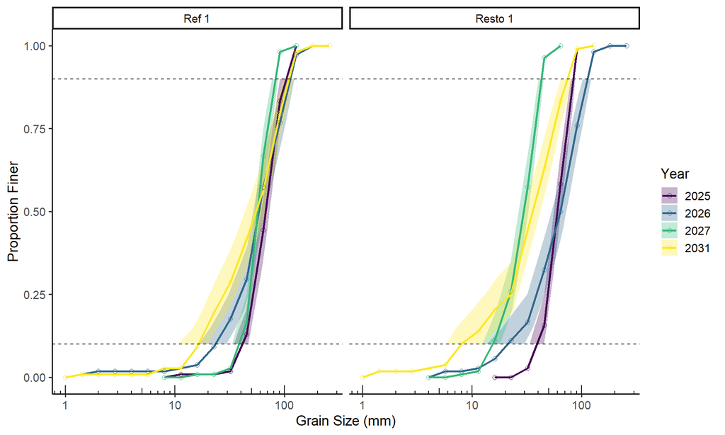

If the confidence intervals do not overlap, a rule of thumb is that the estimates are likely significantly different at the confidence level used to compute the intervals (e.g., 95%). Conversely, if a percentile estimate (e.g.,$D_{50}$) from one sample falls within the confidence interval of the other sample, we cannot reject the null hypothesis that the percentile values are the same.

#### Comparison with Benchmarks - Incubation and Emergence

Remember that we have greater precision for $D_{50}$ values (the median particle diameter) than we can have toward the tails of the distribution due to our sample size. However if salmonid spawning is of interest, it might still be useful to look into patterns that you see toward the smaller end of the distribution. In particular, if there is an excessive or increasing amount of fine particles, you might wish to compare this with benchmark values reported for incubation and emergence (look at the proportion finer than 3, 6, or 10 mm, species-dependent). See Jensen et al 2009, Levy and Slaney 1993, and others.

As a rule of thumb based on *Figure 13.18* in Kondolf et al 2003: if the proportion of surface substrate finer than 1 mm is 0.22 or greater, successful spawning is not anticipated (which you would have probably already noted in the field). With a pebble count, which samples the surface of the gravels, it is simply not possible to ascertain whether subsurface particle sizes are suitable for incubation or emergence. That is, we can confidently say when they are unsuitable, but because there are greater proportions of fines in the subsurface matrix than at the surface, we cannot identify suitable incubation/emergence conditions without bulk sampling.

### Boxplots by Year

To aid with comparing multiple distributions, we will also plot the distributions as box-and-whisker plots. This allows us to visualize the characteristics of individual size distributions side-by-side, whilst avoiding overlapping lines.

The rectangle (box) encompasses the middle 50% of the sample (i.e., interquartile range), from the $D_{25}$ (first quartile) to $D_{75}$ (third quartile) values. The median diameter, $D_{50}$, is represented by a horizontal line through the box. The upper whisker extends to the largest value no further than 1.5 times the inter-quartile range (1.5 x IQR), and the lower whisker extends to the smallest value no further than 1.5 x IQR.

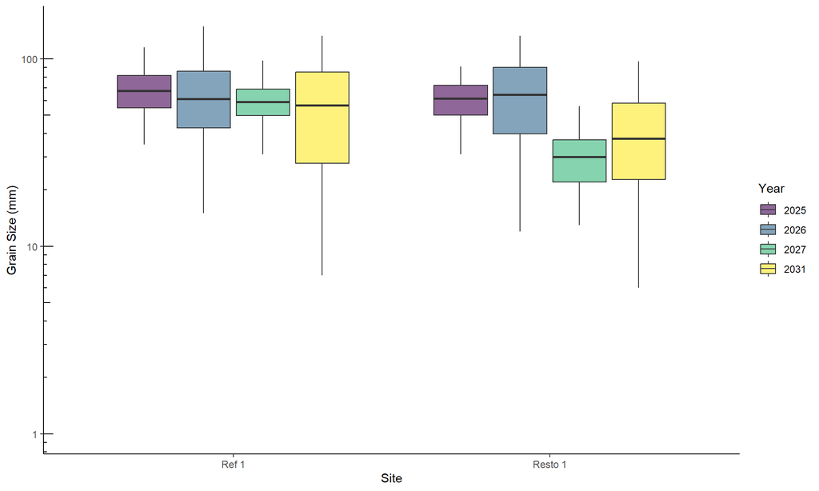

### Cumulative frequency *comparing ‘before’ with ‘after’*

We now establish ‘before’ and ‘after’ groupings for the years of data you collected. We do this because we want to understand the impacts of restoration actions, hoping that the condition after our restoration will be measurably different from the condition before. To do this we will merge the data from years you specify as before, and merge data from the years you specify as after your restoration actions, and compare the ‘before’ and ‘after’ populations. Some important items to note:

- The before/after data and this next plot will differ from the preceding data and plots if you have more than two years of data. If you do not (yet), then this will just be a replicate of the above. However, you must still run the code below to establish the ‘before’ and ‘after’ data, which will be used in the inferential test in the next section.
- Consider the choice of before and after years, without consulting the data itself (which could bias your choice). Your before/after year choices should be grounded in your objectives and *a priori* hypotheses, which might (e.g.) anticipate a time lag between your restoration actions and a change in substrate composition. We recognise that many restoration projects or their impacts may continue over time, perhaps with ongoing stewardship and adaptive management. At the time of writing we do not have code prepared for time-series analyses, but you can still select a subset of years that you consider representative of before and after periods.
- However, once you have confirmed the intended before/after years, you should then take a look at the plots-by-year that we displayed above. If there are notable outlier years, then merging these with ‘normal’ years as one population might not be valid. It is worth looking into these outliers in more depth, and potentially excluding them from the before or after group.
- The before and after categories should balance (equal number of years before as after), but they need not be consecutive years. For example, you could compare 2024 and 2025 ‘before’ data with 2032 and 2034 ‘after’ data. If you do not have balanced categories (due to data collection, or excluded outliers), be very cautious in interpreting results. You could select only a subset of your years to keep the comparison balanced, but if you do this for more than one set of dates you must account for the multiple comparisons inflating the likelihood of a Type I error (false positive). You must also be very aware of the human tendency to bias: Ensure you are not discounting a potential outlier just because it does not fit your expectations.

Enter your before and after years in the below code:

```r
# Define "Before" and "After" years
before_years <- c(2025, 2026) #add more years inside brackets if needed, e.g. 'c(2024, 2025, 2026)'
after_years <- c(2027, 2031) #add more years inside brackets if needed, e.g. 'c(2027, 2029, 2036)'
```

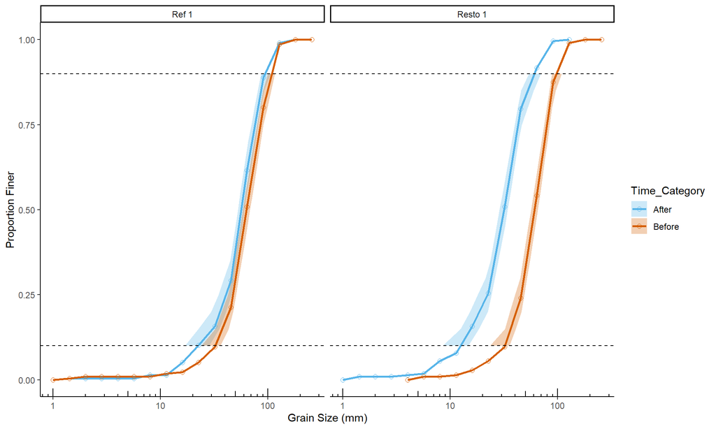

As before, if the confidence intervals do not overlap, a rule of thumb is that the estimates are likely significantly different at the confidence level used to compute the intervals (e.g., 95%). However, in many cases it may not be clear whether the substrate populations are distinct: they may overlap partially, in certain parts of the distribution more than others, etc. This is where inferential statistical tests can be helpful. Below we will implement the two-sample bootstrap resampling tests provided by Eaton et al (2019).

## Two-Sample Inferential Tests

Here we are asking whether the differences between two samples can be attributed to chance, or whether they can be considered statistically significant. We will use `CompareRAWs` (Eaton et al. 2019) which uses the b-axis diameters for every particle and resamples with replacement to generate confidence intervals. Note that they also provide an alternative approach if you collected binned data in the field (e.g. using a gravelometer). Since this statistical method may be unfamiliar, we provide the below excerpt from Eaton et al (2019) describing the steps:

$X_i$ represents b-axis diameters measured in Sample 1, where $_i$ ranges from 1 to $n_{x}$ and $n_{x}$ is the number of grains in Sample 1.

$Y_j$ represents b-axis diameters measured in Sample 2, where $_j$ ranges from 1 to $n_{y}$ and $n_{y}$ is the number of grains in Sample 2.

1. Take a random sample $x$, which comprises a bootstrap sample of $n_{x}$ diameters, with replacement, from the set of values of $X_i$. The order statistics for the bootstrap sample are denoted as $x_{(k)}$, k = 1 to $n_{x}$.
2. Take a random sample $y$, which comprises a bootstrap sample of $n_{y}$ diameters, with replacement, from the set of values of $Y_j$. The order statistics for the bootstrap sample are denoted as $y_{(l)}$, l = 1 to $n_{y}$.
3. Determine the desired percentile value from each bootstrap sample, $(dp)_x$ and $(dp)_y$, and compute the difference, $\Delta dp$ = $(dp)_x$ - $(dp)_y$.
4. Repeat steps 1 to 3 $n_r$ times (e.g., $n_r$ = 1000), each time storing the value of $\Delta dp$.
5. Determine a confidence interval for $\Delta dp$ by computing the quantiles corresponding to $\alpha$/2 and 1-$\alpha$/2, where $\alpha$ is the desired significance level for the test (e.g., $\alpha$ = 0.05).
6. If the confidence interval determined in Step 5 does not overlap 0, then we can reject the null hypothesis that the sampled populations have the same value of $D_P$.

Before running the test, you should remind yourself of your *a priori* hypotheses and predictions, and consider which percentile is of interest to you. Our default is $D_{50}$, because of the level of precision available with sample sizes of ~100, and because of the familiarity and interpretability of the median. However, different percentiles can be chosen through simple amendments of the code, and if you understand the implications of multiple comparisons and the risk of *post-hoc* justifications, you can generate tests of every percentile simultaneously. It is also possible to adjust the alpha (p-value) from the default of 0.05.

```
##   Percentile Sample_1 Sample_2 Stat_Diff    Site
## 1         50       64     58.5     FALSE   Ref 1
## 2         50       62     32.0      TRUE Resto 1
```

The above table indicates the percentile chosen, the value of that percentile in sample 1 (before) and sample 2 (after), and indicates whether there is a statistically significant difference (TRUE or FALSE) for that percentile.

# Interpretation

By this point, you have visualisations of the pebble count data structured by year and structured as ‘before vs after’ the restoration action. You also have the results of a statistical test. It is over to your expertise and that of your partners to interpret what this all means, taking all of these outputs together.

It is worth noting that, with this approach, we do not have an inferential test that includes an ‘interaction’ term. As such, we cannot directly assess whether any changes at the restoration site over time are distinct from changes at the control site over time (only that each of these changes was or was not a real change in particle size distributions). In cases where a restoration site and a control site both change in the direction that you hypothesized would result from your restoration action, we recommend considering any differences in magnitude of the changes, the shapes of the distribution, and the yearly variability (if several years of data are available). Differences in these features may help to partition the observed change between background variability and your restoration actions.

Once you have grasped the information about the changes (or absence of such) in particle sizes, move onto considering the biological and/or morphological significance and the implications for your project. Consider any benchmarks that you can refer to: If salmonid spawning was your focus, did the particle distributions return to a range that fish are known to use? And consider what any directional change implies: Is the relative change in median particle size indicative of a successful attempt to mitigate peak flows in the system?

Although we consider interpretation the hardest step, and we leave it entirely to you, we hope that our support in visualising and exploring your data has been helpful. Keep up the good work!

# References

Eaton, B. C., Moore, R.D, & Mackenzie, L. G. (2019). Percentile-based grain size distribution analysis tools (GSDtools)-Estimating confidence limits and hypothesis tests for comparing two samples. Earth Surface Dynamics, 7(3), 789–806. https://doi.org/10.5194/esurf-7-789-2019

Eaton, B. C. and Moore, R. D.: GSDtools: analyse and compare river bed surface grain size distributions (R Package), Zenodo, https://doi.org/10.5281/zenodo.3229387, 201

Jensen D.W., Steel E.A., Fullerton A.H., Pess G.R. (2009). Impact of fine sediment on egg-to-fry survival of Pacific salmon: a meta-analysis of published studies. Reviews in Fisheries Science 17: 348–359. DOI:10.1080/10641260902716954.

Kondolf, G.M. (2000). Assessing salmonid spawning gravels. Transactions of the American Fisheries Society 129: 262-281.

Kondolf, G.M., Lisle, T.E., & Wolman, G.M. (2003). Bed sediment measurement. Tools in fluvial geomorphology, 347, p.395.

Levy, D. A., & Slaney, T. L. (1993). A review of habitat capacity for salmon spawning and rearing. Resources Inventory Committee.

Overstreet, B. T., C. S. Riebe, J. K. Wooster, L. S. Sklar, and D. Bellugi (2016), Tools for gauging the capacity of salmon spawning substrates, Earth Surf. Process. Landforms, 41(1), 130–142, doi:10.1002/esp.3831

Riebe, C. S., L. S. Sklar, B. T. Overstreet, and J. K. Wooster (2014), Optimal reproduction in salmon spawning substrates linked to grain size and fish length, Water Resour. Res., 50, 898–918, doi:10.1002/2013wr014231.